# Part I - Prosper Loan Data Visualisation

## Introduction

> This is an exploratory data analysis of the loan data from Prosper. Prosper runs a website where individuals can either invest in personal loans or request to borrow money.

> The Prosper Loan data set contains 113,937 loans with 81 variables on each loan, including loan amount, borrower rate (or interest rate), current loan status, borrower income, and many others.

## Preliminary Wrangling

```python
# import all packages and set plots to be embedded inline
import numpy as np
import pandas as pd
import matplotlib.pyplot as plt
import seaborn as sb

%matplotlib inline
```

```python
# load dataset into a pandas dataframe
prosper = pd.read_csv('prosperLoanData.csv')
prosper.head(5)
```

|  | ListingKey | ListingNumber | ListingCreationDate | CreditGrade | Term | LoanStatus | ClosedDate | BorrowerAPR | BorrowerRate | LenderYield | ... | LP_ServiceFees | LP_CollectionFees | LP_GrossPrincipalLoss | LP_NetPrincipalLoss | LP_NonPrincipalRecoverypayments | PercentFunded | Recommendations | InvestmentFromFriendsCount | InvestmentFromFriendsAmount | Investors |
| --- | --- | --- | --- | --- | --- | --- | --- | --- | --- | --- | --- | --- | --- | --- | --- | --- | --- | --- | --- | --- | --- |
| 0 | 1021339766868145413AB3B | 193129 | 2007-08-26 19:09:29.263000000 | C | 36 | Completed | 2009-08-14 00:00:00 | 0.16516 | 0.1580 | 0.1380 | ... | -133.18 | 0.0 | 0.0 | 0.0 | 0.0 | 1.0 | 0 | 0 | 0.0 | 258 |
| 1 | 10273602499503308B223C1 | 1209647 | 2014-02-27 08:28:07.900000000 | NaN | 36 | Current | NaN | 0.12016 | 0.0920 | 0.0820 | ... | 0.00 | 0.0 | 0.0 | 0.0 | 0.0 | 1.0 | 0 | 0 | 0.0 | 1 |
| 2 | 0EE9337825851032864889A | 81716 | 2007-01-05 15:00:47.090000000 | HR | 36 | Completed | 2009-12-17 00:00:00 | 0.28269 | 0.2750 | 0.2400 | ... | -24.20 | 0.0 | 0.0 | 0.0 | 0.0 | 1.0 | 0 | 0 | 0.0 | 41 |
| 3 | 0EF5356002482715299901A | 658116 | 2012-10-22 11:02:35.010000000 | NaN | 36 | Current | NaN | 0.12528 | 0.0974 | 0.0874 | ... | -108.01 | 0.0 | 0.0 | 0.0 | 0.0 | 1.0 | 0 | 0 | 0.0 | 158 |
| 4 | 0F023589499656230C5E3E2 | 909464 | 2013-09-14 18:38:39.097000000 | NaN | 36 | Current | NaN | 0.24614 | 0.2085 | 0.1985 | ... | -60.27 | 0.0 | 0.0 | 0.0 | 0.0 | 1.0 | 0 | 0 | 0.0 | 20 |

5 rows × 81 columns

```python
# prints information about the dataset
prosper.info()
```

```
<class 'pandas.core.frame.DataFrame'>
RangeIndex: 113937 entries, 0 to 113936
Data columns (total 81 columns):
 #   Column                               Non-Null Count   Dtype
---  ------                               --------------   -----
 0   ListingKey                           113937 non-null  object
 1   ListingNumber                        113937 non-null  int64
 2   ListingCreationDate                  113937 non-null  object
 3   CreditGrade                          28953 non-null   object
 4   Term                                 113937 non-null  int64
 5   LoanStatus                           113937 non-null  object
 6   ClosedDate                           55089 non-null   object
 7   BorrowerAPR                          113912 non-null  float64
 8   BorrowerRate                         113937 non-null  float64
 9   LenderYield                          113937 non-null  float64
```

[output cut: 73 more lines]

```python
# overview of data shape
print(prosper.shape)
```

```
(113937, 81)
```

### What is the structure of your dataset?

> The dataset has 113,937 rows and 81 columns

### What is/are the main feature(s) of interest in your dataset?

> What factors affect a loan’s outcome status?

> What affects the borrower’s interest rate? Is it employment status, income range, term

## Univariate Exploration

```python
# Returns the sum of borrowers with prior facilities

prosper['TotalProsperLoans'].sum()
```

```
31385.0
```

```python
# Combine the ratings of borrowers prior to 2019 and after 2019 using the melt function

creditrating = prosper.melt(id_vars = ['LoanOriginalAmount'], value_vars = ['CreditGrade', 'ProsperRating (Alpha)'],
                            var_name = 'ratingtype', value_name = 'rating').dropna()
creditrating
```

|  | LoanOriginalAmount | ratingtype | rating |
| --- | --- | --- | --- |
| 0 | 9425 | CreditGrade | C |
| 2 | 3001 | CreditGrade | HR |
| 11 | 1000 | CreditGrade | C |
| 17 | 10000 | CreditGrade | AA |
| 21 | 3000 | CreditGrade | D |
| ... | ... | ... | ... |
| 227869 | 10000 | ProsperRating (Alpha) | C |
| 227870 | 2000 | ProsperRating (Alpha) | A |
| 227871 | 10000 | ProsperRating (Alpha) | D |
| 227872 | 15000 | ProsperRating (Alpha) | C |
| 227873 | 2000 | ProsperRating (Alpha) | A |

113806 rows × 3 columns

```python
# get order of bars by credit rating

x = creditrating['rating'].value_counts().sort_index().index
x
```

```
Index(['A', 'AA', 'B', 'C', 'D', 'E', 'HR', 'NC'], dtype='object')
```

```python
y = creditrating['rating'].value_counts().sort_index(ascending = True)
y
```

```
A     17866
AA     8881
B     19970
C     23994
D     19427
E     13084
HR    10443
NC      141
Name: rating, dtype: int64
```

```python
creditrating['rating'].describe()
```

```
count     113806
unique         8
top            C
freq       23994
Name: rating, dtype: object
```

```python
#create a function for countplot
def cplot(prosper, xvar):
    plt.figure(figsize = [10,7])
    color = sb.color_palette()[0]
    sb.countplot(data = prosper, x = xvar, color = color)
    plt.title(f'''Distribution of {xvar}'''.title(), fontsize = 20)
```

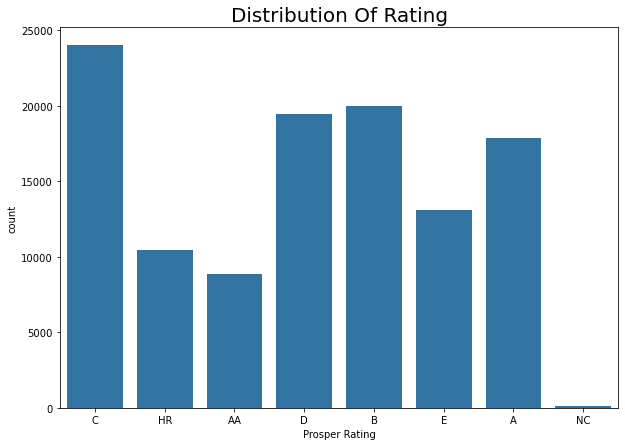

```python
#Prosper Rating Count
cplot(creditrating, 'rating')
plt.xlabel('Prosper Rating')
plt.ylabel('count');
```

```python
prosper['LoanStatus'].value_counts()
```

```
Current                   56576
Completed                 38074
Chargedoff                11992
Defaulted                  5018
Past Due (1-15 days)        806
Past Due (31-60 days)       363
Past Due (61-90 days)       313
Past Due (91-120 days)      304
Past Due (16-30 days)       265
FinalPaymentInProgress      205
Past Due (>120 days)         16
Cancelled                     5
Name: LoanStatus, dtype: int64
```

```python
# Replace Past Due with Defaulted
prosper['LoanStatus'].replace(['Past Due (1-15 days)','Past Due (16-30 days)',
                               'Past Due (31-60 days)', 'Past Due (61-90 days)',
                               'Past Due (91-120 days)', 'Past Due (>120 days)'],
                              'Defaulted', inplace = True)
```

```python
prosper['LoanStatus'].replace(['Cancelled'], 'Chargedoff', inplace = True)
```

```python
# Replace FinalPaymentInProgress with Current
prosper['LoanStatus'].replace(['FinalPaymentInProgress'], 'Current', inplace = True)
```

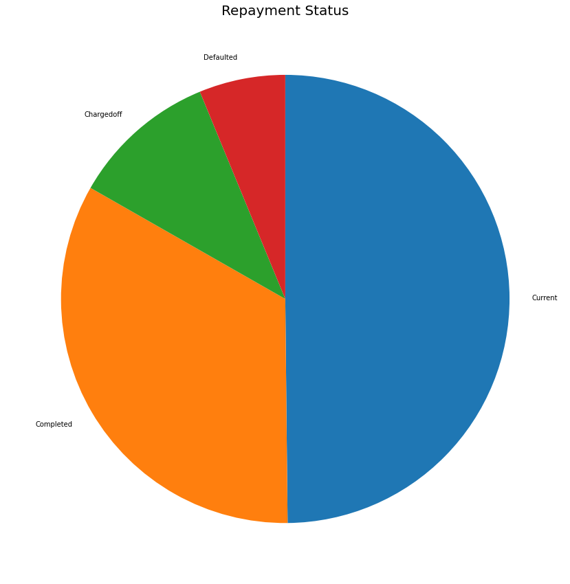

```python
#loan status distribution
plt.figure(figsize = [15,15])
loanstatus = prosper['LoanStatus'].value_counts();
plt.pie(loanstatus, labels = loanstatus.index, startangle = 90, counterclock = False)
plt.title('Repayment Status', fontsize = 20);
```

```python
prosper['IncomeRange'].value_counts()
```

```
$25,000-49,999    32192
$50,000-74,999    31050
$100,000+         17337
$75,000-99,999    16916
Not displayed      7741
$1-24,999          7274
Not employed        806
$0                  621
Name: IncomeRange, dtype: int64
```

```python
#replace as a person who doesn't earn is as good as a person who is unemployed
prosper['IncomeRange'].replace(['Not employed'], '$0', inplace = True)
```

```python
inc_order = ['$0', '$1-24,999', '$100,000+', '$25,000-49,999', '$50,000-74,999','$75,000-99,999']
inc_order
```

```
['$0',
 '$1-24,999',
 '$100,000+',
 '$25,000-49,999',
 '$50,000-74,999',
 '$75,000-99,999']
```

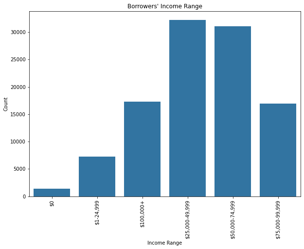

```python
# Borrowers income range
plt.figure(figsize =[10,7])
color = sb.color_palette()[0]
plt.title("Borrowers' Income Range")
sb.countplot(data = prosper, x = 'IncomeRange', color = color, order = inc_order)
plt.xlabel('Income Range')
plt.ylabel('Count')
plt.xticks(rotation = 90);
```

```python
# convert 'EmploymentStatus' to categorical data type
estatus = ['Not employed', 'Not available', 'Other', 'Self-employed','Part-time','Full-time','Employed', 'Retired']
emp_order = pd.api.types.CategoricalDtype(ordered = True, categories = estatus)
prosper['EmploymentStatus'] = prosper['EmploymentStatus'].astype(emp_order)
```

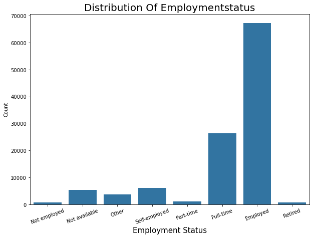

```python
# employment status count
cplot(prosper, 'EmploymentStatus')
plt.xlabel('Employment Status', fontsize = 15)
plt.ylabel('Count')
plt.xticks(rotation = 20);
```

```python
prosper['ListingCategory (numeric)'].value_counts().sort_index().index
```

```
Int64Index([0, 1, 2, 3, 4, 5, 6, 7, 8, 9, 10, 11, 12, 13, 14, 15, 16, 17, 18,
            19, 20],
           dtype='int64')
```

```python
l_category = [0, 1, 2, 3, 4, 5, 6, 7, 8, 9, 10, 11, 12, 13, 14, 15, 16, 17, 18,
            19, 20]
```

```python
listing = pd.api.types.CategoricalDtype(ordered=True, categories = l_category)
prosper['ListingCategory (numeric)'] = prosper['ListingCategory (numeric)'].astype(listing)
```

```python
prosper['ListingCategory (numeric)'] = prosper['ListingCategory (numeric)'].cat.rename_categories({0: 'Not Available', 1: 'Debt Consolidation', 2: 'Home Improvement', 3: 'Business',
                                                                                                   4: 'Personal Loan', 5: 'Student Use', 6: 'Auto', 7: 'Other', 8: 'Baby&Adoption',
                                                                                                  9: 'Boat', 10: 'Cosmetic Procedure', 11: 'Engagement Ring',12: 'Green Loans',
                                                                                                  13: 'Household Expenses', 14: 'Large Purchases', 15: 'Medical/Dental',
                                                                                                  16: 'Motorcycle', 17: 'RV', 18: 'Taxes', 19: 'Vacation', 20: 'Wedding Loans'})
```

```python
prosper['ListingCategory (numeric)'].value_counts()
```

```
Debt Consolidation    58308
Not Available         16965
Other                 10494
Home Improvement       7433
Business               7189
Auto                   2572
Personal Loan          2395
Household Expenses     1996
Medical/Dental         1522
Taxes                   885
Large Purchases         876
Wedding Loans           771
Vacation                768
Student Use             756
Motorcycle              304
Engagement Ring         217
Baby&Adoption           199
Cosmetic Procedure       91
Boat                     85
Green Loans              59
RV                       52
Name: ListingCategory (numeric), dtype: int64
```

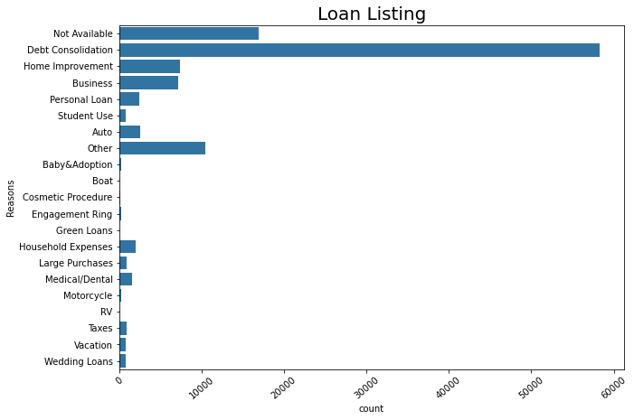

```python
# employment status count
plt.figure(figsize =[10,7])
sb.countplot(data = prosper, y = 'ListingCategory (numeric)', color = color)
plt.title('Loan Listing', fontsize = 20)
plt.ylabel('Reasons')
plt.xticks(rotation = 40);
```

```python
#get the minimum and maximum interest rates
prosper.BorrowerRate.describe()
```

```
count    113937.000000
mean          0.192764
std           0.074818
min           0.000000
25%           0.134000
50%           0.184000
75%           0.250000
max           0.497500
Name: BorrowerRate, dtype: float64
```

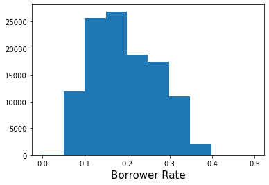

```python
plt.hist(data = prosper, x = 'BorrowerRate');
plt.xlabel('Borrower Rate', fontsize = 15);
```

### Discuss the distribution(s) of your variable(s) of interest. Were there any unusual points? Did you need to perform any transformations?

> Most of the borrowers had average ratings with normal distribution.

> For the loan status variable, it can be seen from the pie chart that most of the loans are currently running, followed closely by loans which have been completed. The loan status looks good as not a lot of the loans defaulted or needed to be charged off. Would investigate more as we go an as to the major factors that influence a loan's outcome

> The income range as seen using a bar chart seems to be evenly distributed with most of the borroers earning between'$25,000-to $74,999'

> A huge portion of the borrowers are employed, be it self employment, part time employment or full time,

> Numeric values were used to represent the listing categories. The numbers were replaced with their meanings found in the documentation. This shows that a lot of borrowers took loans for Debt Consolidation.

### Of the features you investigated, were there any unusual distributions? Did you perform any operations on the data to tidy, adjust, or change the form of the data? If so, why did you do this?

> The not employed rows for income range were replaced with 0 as it implied the same thing.

> For the Credit rating, the 'CreditGrade' and 'ProsperRating (Alpha)' columns were combined as the Credit Grade system was pre 2009 and the Prosper Rating system was post 2009. This was to enable us view the ratings for all the borrowers at a glance.

> The Listing Categories were replaced from numbers to their listings as seen in the data dictionary

## Bivariate Exploration

> In this section, we are going to be investigating relationships between pairs of variables in our data.

```python
#view distribution of home owners among borrowers
prosper['IsBorrowerHomeowner'].value_counts()
```

```
True     57478
False    56459
Name: IsBorrowerHomeowner, dtype: int64
```

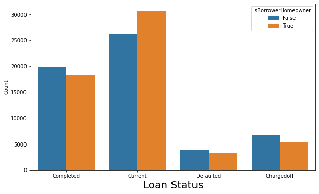

```python
plt.figure(figsize= [10,6])
sb.countplot(data = prosper, x = 'LoanStatus', hue = 'IsBorrowerHomeowner');
plt.ylabel('Count')
plt.xlabel('Loan Status', fontsize = 20);
```

For loans which have been completed, you have less home ownwers and same applies to defaults. However for the current and running loans you have more house owners. This might be becuase people are taking the loans for home improvement and also debt consolidation in cases where they have mortgages

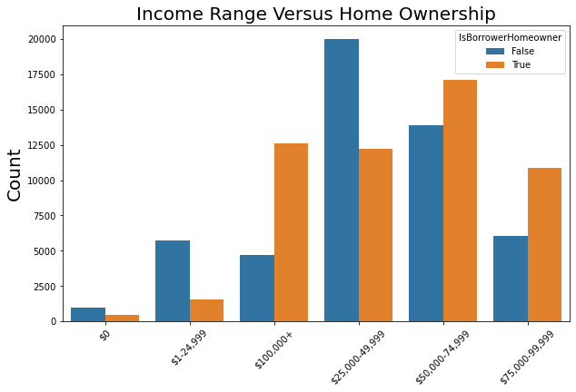

```python
plt.figure(figsize= [10,6])
sb.countplot(data = prosper, x = 'IncomeRange', hue = 'IsBorrowerHomeowner', order = inc_order);
plt.title('Income Range Versus Home Ownership', fontsize = 20)
plt.ylabel('Count', fontsize = 20)
plt.xlabel('', fontsize = 20);
plt.xticks(rotation = 45);
```

> For the top salary range(25,000 - 49,999), we have less home owners

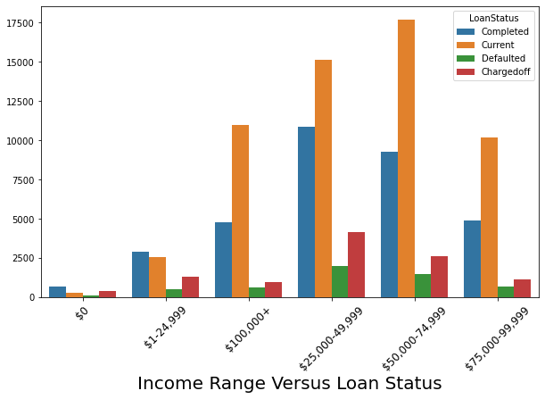

```python
plt.figure(figsize= [10,6])
sb.countplot(data = prosper, x = 'IncomeRange', hue = 'LoanStatus', order = inc_order);
plt.xlabel('Income Range Versus Loan Status', fontsize = 20);
plt.ylabel('', fontsize = 20)
plt.xticks(rotation = 45, fontsize = 12);
```

> It is Left skewed with the $50 range with the highest number of current loans

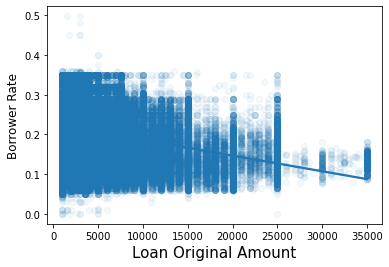

```python
#Scatter plot showing the relationship between the loan amount and rate
sb.regplot(data = prosper, x = 'LoanOriginalAmount', y = 'BorrowerRate', x_jitter= 0, scatter_kws={'alpha':1/20});
plt.xlabel('Loan Original Amount', fontsize = 15);
plt.ylabel('Borrower Rate', fontsize = 12);
```

The regression line in the scatter plot shows a negative correlation between the loan amount and the rate

```python
# Convert the "rating" column from a plain object type into an ordered categorical type
grade = ['A', 'AA', 'B', 'C', 'D', 'E', 'HR', 'NC']
sort_grade = pd.api.types.CategoricalDtype(ordered = True, categories = grade)
creditrating['rating'] = creditrating['rating'].astype(sort_grade)
```

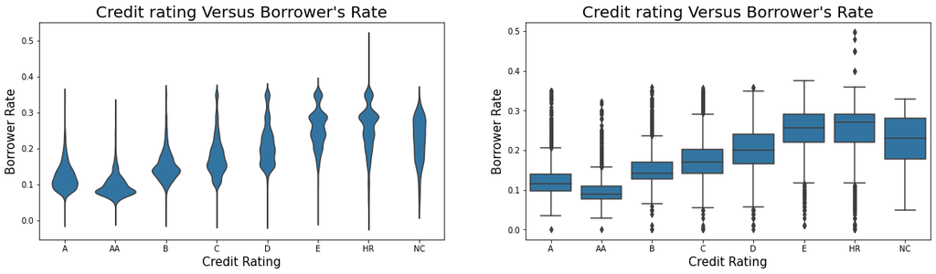

```python
#borrower's rating against borrower's rate
plt.figure(figsize = [20,5])

plt.subplot(1,2,1)
plt.title("Credit rating Versus Borrower's Rate", fontsize = 20)
sb.violinplot(data = prosper, x = creditrating['rating'], y = 'BorrowerRate', color = color, inner = None);
plt.xlabel('Credit Rating', fontsize = 15);
plt.ylabel('Borrower Rate', fontsize = 15);

plt.subplot(1,2,2)
plt.title("Credit rating Versus Borrower's Rate", fontsize = 20)
sb.boxplot(data = prosper, x= creditrating['rating'], y = 'BorrowerRate', color = color);
plt.xlabel('Credit Rating', fontsize = 15);
plt.ylabel('Borrower Rate', fontsize = 15);
```

> There is a negative correlation between the prosper rating and the borrower's rate. The borrower's rate increases as the credit rating declines. However, there are outliers in the data as some customers with A rating have really high interest rates and customers wth E and HR rating also seem to have low interest rates. This would imply that the ratings are not the only metrics used to determine borrower's rate

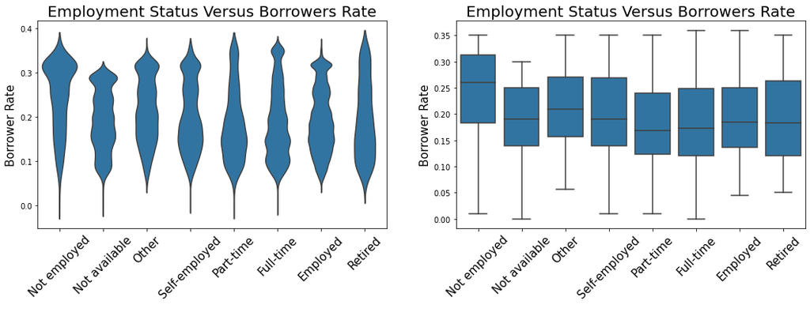

```python
#Employment Status versus borrower's rate
plt.figure(figsize = [18,5])

plt.subplot(1,2,1)
sb.violinplot(data = prosper, x = 'EmploymentStatus', y = 'BorrowerRate', color = color, inner = None);
plt.title('Employment Status Versus Borrowers Rate', fontsize = 20);
plt.xticks(rotation = 45, fontsize = 15);
plt.xlabel('', fontsize = 10);
plt.ylabel('Borrower Rate', fontsize = 15);
;

plt.subplot(1,2,2)
sb.boxplot(data = prosper, x= 'EmploymentStatus', y = 'BorrowerRate', color = color);
plt.title('Employment Status Versus Borrowers Rate', fontsize = 20);
plt.xticks(rotation = 45, fontsize = 15);
plt.xlabel(' ',fontsize = 10)
plt.ylabel('Borrower Rate', fontsize = 15);
```

> The employment status seems to have a negative corelation with the borrower rate. From the plots above we can deduce that borrowers who are not employed and others have higher rates.

### Talk about some of the relationships you observed in this part of the investigation. How did the feature(s) of interest vary with other features in the dataset?

> It would seem that borrowers that aren't home owners are more likely to default

### Did you observe any interesting relationships between the other features (not the main feature(s) of interest)?

> The higher the loan amount, the lower the borrower rates

## Multivariate Exploration

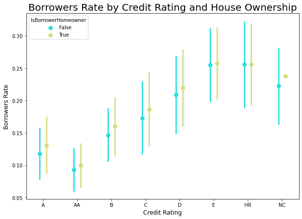

```python
#Compare the relationship between credit rating and rate and home ownership
plt.figure(figsize = [10,7])
sb.pointplot(data = prosper, x = creditrating['rating'], y = 'BorrowerRate', hue = 'IsBorrowerHomeowner',
            ci='sd', linestyles = "", palette = 'rainbow', dodge = 0.2)
plt.title('Borrowers Rate by Credit Rating and House Ownership', fontsize = 20)
plt.ylabel('Borrowers Rate', fontsize = 12);
plt.xlabel('Credit Rating', fontsize = 12);
```

> This focuses on how the credit rating and home ownership impact the Borrowers rate.

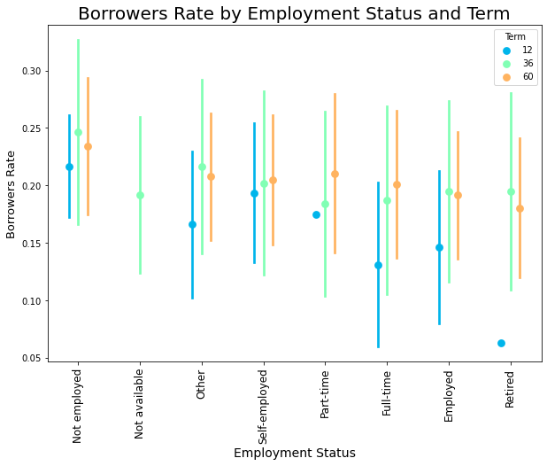

```python
plt.figure(figsize = [10,7])
sb.pointplot(data = prosper, x = 'EmploymentStatus', y ='BorrowerRate' , hue = 'Term',
            ci='sd', linestyles = "" , palette = 'rainbow', dodge = 0.3)
plt.title('Borrowers Rate by Employment Status and Term', fontsize = 20);
plt.ylabel('Borrowers Rate', fontsize = 13);
plt.xlabel('Employment Status', fontsize = 14);
plt.xticks(rotation = 90, fontsize = 12);
```

> This examines how the loan term interacts with the the employment status and borrower's rate

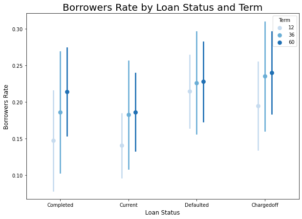

```python
#Compare the relationship between credit rating and rate and home ownership
plt.figure(figsize = [10,7])
sb.pointplot(data = prosper, x = 'LoanStatus', y = 'BorrowerRate', hue = 'Term',
            ci='sd', linestyles = "", palette = 'Blues', dodge = 0.2)
plt.title('Borrowers Rate by Loan Status and Term', fontsize = 20)
plt.ylabel('Borrowers Rate', fontsize = 12);
plt.xlabel('Loan Status', fontsize = 12);
```

> The plot illustrate how loan status outcome is affected by borrower's rate and term of the loan

### Talk about some of the relationships you observed in this part of the investigation. Were there features that strengthened each other in terms of looking at your feature(s) of interest?

> The relationship between the loan term and rate is positive as the longer the loan term, the higher the interest rates.

> We can also confirm that employment status is a contributing factor to the loan rates

> The credit rate is a major contributing factor to borrower's rates. The lower the credit score, the higher the rates as the customer could possibly default.

### Were there any interesting or surprising interactions between features?

> Borrowers rate is higher for loans that have defaulted. This might be a contributing factor to the defaults.Except if the rates are raised after borrowers default.

## Conclusions

> Homeowners are also less likely to default as their houses can act as collateral

> Employment status was also a contributing factor to borrower's rate